# LectureNotebook_01_key

Christopher Moore

2/18/2018

### 1.1

By hand, compute the expected number of individuals over time in a population with a single initial individual that grows according to equation 3 for $\lambda = 1.9$, $\lambda = 2.0$, and $\lambda = 2.1$, where $\lambda$ is the finite rate of increase. Enter your data in R using `c()` for 10 timesteps. For example: `lambda_1.9 <- c(1, 1.9)` (but with nine more entries). Plot the data as points and use the function `points()` to present all three trajectories on a single plot. Plot your data as a timeseries, meaning the horizontal axis is time (or timesteps, in this instance).

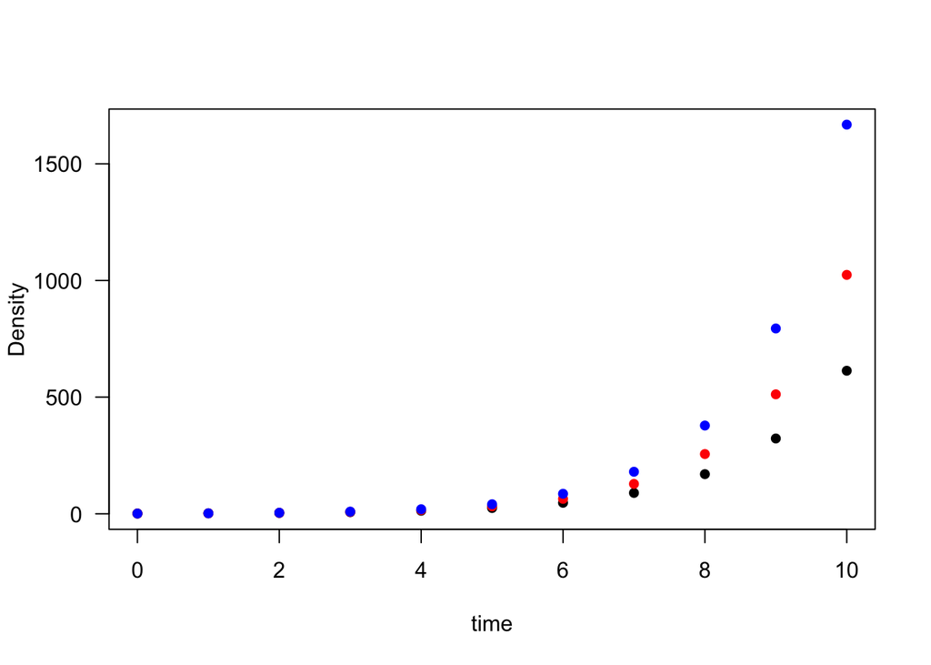

```r
lam1.9 <- c(1, 1.9, 3.61, 6.859, 13.0321, 24.76099, 47.04588, 89.38717, 169.83563, 322.68770, 613.10663)
lam2.0 <- c(1, 2, 4, 8, 16, 32, 64, 128, 256, 512, 1024)
lam2.1 <- c(1, 2.1, 4.41, 9.261, 19.4481, 40.84101, 85.76612, 180.10885, 378.22859, 794.28005, 1667.98810)
times <- seq(from = 0, to = 10, by = 1)
plot(x = NA, type = "n", xlim = c(0, 10), ylim = c(0, max(c(lam1.9, lam2.0, lam2.1))), xlab = "time", ylab = "Density", las = 1)
  points(x = times, y = lam1.9, col = "black", pch = 16)
  points(x = times, y = lam2.0, col = "red", pch = 16)
  points(x = times, y = lam2.1, col = "blue", pch = 16)
```

### 1.2

Plot the numbers aclculated in exercise 1.1 as ln($N$) versus time. Do this by creating a new object that is the natural log of the data from exercise 1.1. Plot all three growth curves again using the function `points()`. Calculate and report the equations of the three curves (lines are technically a type of curve, should that be what your data show). To write out math, just put dollar signs around your text: `$\lambda = 1.9$` (looks like $\lambda = 1.9$).

```r
log1.9 <- log(lam1.9)
log2.0 <- log(lam2.0)
log2.1 <- log(lam2.1)
summary(lm(log1.9 ~ times))
```

```
##
## Call:
## lm(formula = log1.9 ~ times)
##
## Residuals:
##        Min         1Q     Median         3Q        Max
## -3.778e-08  2.665e-09  3.888e-09  4.622e-09  1.420e-08
##
## Coefficients:
##               Estimate Std. Error    t value Pr(>|t|)
## (Intercept) -2.421e-09  8.757e-09 -2.760e-01    0.788
## times        6.419e-01  1.480e-09  4.336e+08   <2e-16 ***
## ---
## Signif. codes:  0 '***' 0.001 '**' 0.01 '*' 0.05 '.' 0.1 ' ' 1
##
## Residual standard error: 1.552e-08 on 9 degrees of freedom
## Multiple R-squared:      1,  Adjusted R-squared:      1
## F-statistic: 1.88e+17 on 1 and 9 DF,  p-value: < 2.2e-16
```

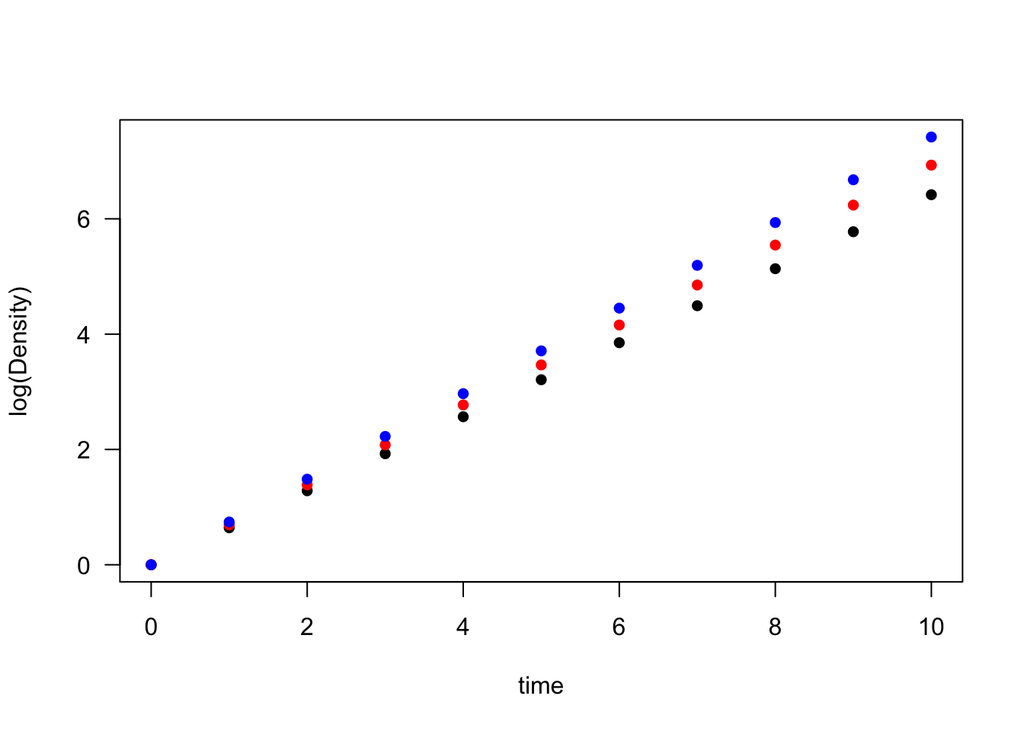

```r
plot(x = NA, type = "n", xlim = c(0, 10), ylim = c(0, max(c(log1.9, log2.0, log2.1))), xlab = "time", ylab = "log(Density)", las = 1)
  points(x = times, y = log1.9, col = "black", pch = 16)
  points(x = times, y = log2.0, col = "red", pch = 16)
  points(x = times, y = log2.1, col = "blue", pch = 16)
```

### 1.3

Derive an equation for doubling time in an exponentially growing population, and derive one for tripling time.

If $N(t) = N(0)e^{rt}$, and we want to double or triple the initial population, we respectively seek the ratios $\frac{N(t)}{N(0)} = 2$ and $\frac{N(t)}{N(0)} = 3$. How long that takes means we must then solve for $t$. If $x = e^{rt}$, solving for $t$ would require taking the log (natural) of both sides, then dividing both sides by $r$, leaving us with $\frac{\log (x)}{r} = t$. For doubling time let $x = 2$ and for tripling time let $x = 3$.

### 1.4

Plot the values computed in exercise 1.1 on a graph of $N_{t+1}$ on the vertical axis and $N_t$ on the horizontal axis for each value of $\lambda$ on a single graph. This time plot them as lines using the function `lines()` after `points()`.

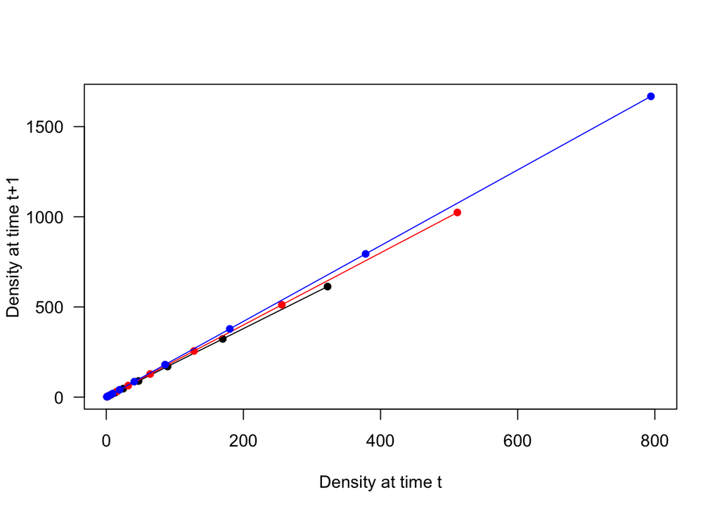

```r
plot(x = NA, type = "n", xlim = c(0, 800), ylim = c(0, 1668), xlab = "Density at time t", ylab = "Density at time t+1" , las = 1)
  points(x = lam1.9[-11], y = lam1.9[-1], col = "black", pch = 16)
  lines(x = lam1.9[-11], y = lam1.9[-1], col = "black")
  points(x = lam2.0[-11], y = lam2.0[-1], col = "red", pch = 16)
  lines(x = lam2.0[-11], y = lam2.0[-1], col = "red")
  points(x = lam2.1[-11], y = lam2.1[-1], col = "blue", pch = 16)
  lines(x = lam2.1[-11], y = lam2.1[-1], col = "blue")
```

### 1.5

The human population on a small island nation is said to be doubling every 20 years. What would be the value of $r$ (assuming an exponential model)? In $2 = \frac{N(20)}{N(0)} = e^{r(20)}$, then we are trying to solve for $r$. In this case, we take the natural log of both sides and divide by $t = 20$, giving $r = \frac{\log (2)}{20} = 0.03465736$.

### 1.6

Using the differential form (i.e., continuous time), suppose that $r = 0.5$. Compute $N$ as a function of $t$, again beginning with a single individual. Do the same for $r = 1.5$ and for $r = 1$. Graph all of the results.

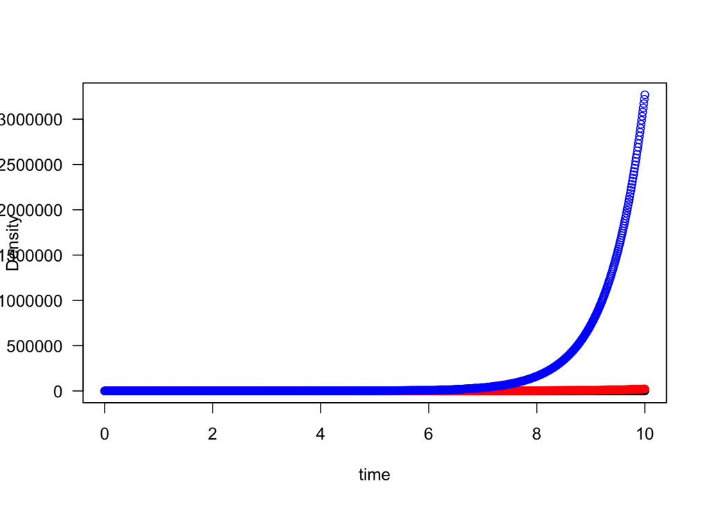

```r
# Use the solution to the exponetial equation to solve for N at time t from an inital N of 1 (here, until t = 10)
times <- seq(from = 0, to = 10, by = 0.01)
r0.5 <- 1*exp(0.5*times)
r1.0 <- 1*exp(1.0*times)
r1.5 <- 1*exp(1.5*times)
plot(x = NA, type = "n", xlim = c(0, 10), ylim = c(0, max(r1.5)), xlab = "time", ylab = "Density", las = 1)
  points(x = times, y = r0.5, col = "black", pch = 1)
  points(x = times, y = r1.0, col = "red", pch = 1)
  points(x = times, y = r1.5, col = "blue", pch = 1)
```

### 1.7

Plot the derivative (which you can approximate by subtracting the current $N$ from its successive on and dividing by the change in time) as a function of $N$ for the data calculated in exercise 1.6 (use a small time interval, e.g., 0.01).

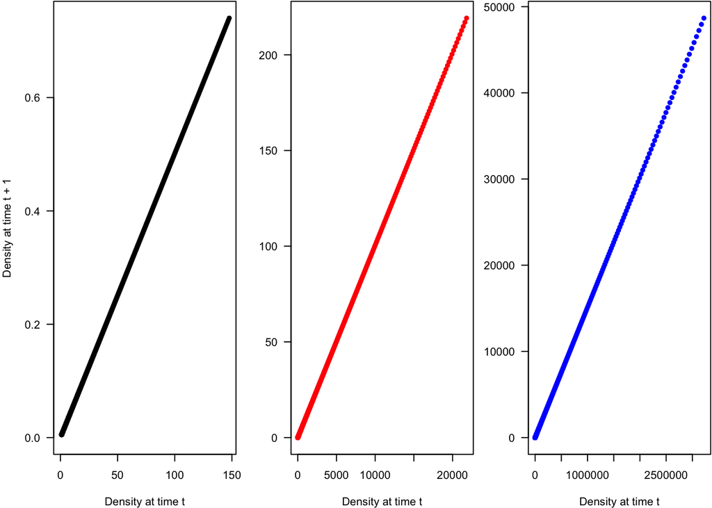

```r
len.t <- length(times)
#  len.t # we know how many ts we calcualtes
r0.5t <- r0.5[-len.t]
r0.5t1 <- r0.5[-1]
diff0.5 <- r0.5t1 - r0.5t
diff1.0 <- r1.0[-1] - r1.0[-len.t]
diff1.5 <- r1.5[-1] - r1.5[-len.t]
par(mar = c(4, 4, 0.1, 0.1), mfrow = c(1, 3))
plot(x = r0.5t, y = diff0.5, pch = 16, xlim = c(0, max(r0.5t)), ylim = c(0, max(diff0.5)), xlab = "Density at time t", ylab = "Density at time t + 1", las = 1)
plot(x = r1.0[-len.t], y = diff1.0, pch = 16, col = "red", xlim = c(0, max(r1.0[-len.t])), ylim = c(0, max(diff1.0)), xlab = "Density at time t", ylab = "", las = 1)
plot(x = r1.5[-len.t], y = diff1.5, pch = 16, col = "blue", xlim = c(0, max(r1.5[-len.t])), ylim = c(0, max(diff1.5)), xlab = "Density at time t", ylab = "", las = 1)
```

### 1.8

From the data calculated in exercise 1.7, divide the estimated derivative by the average number of individuals during the time period, and plot them over time. What is the result, and what does it mean?

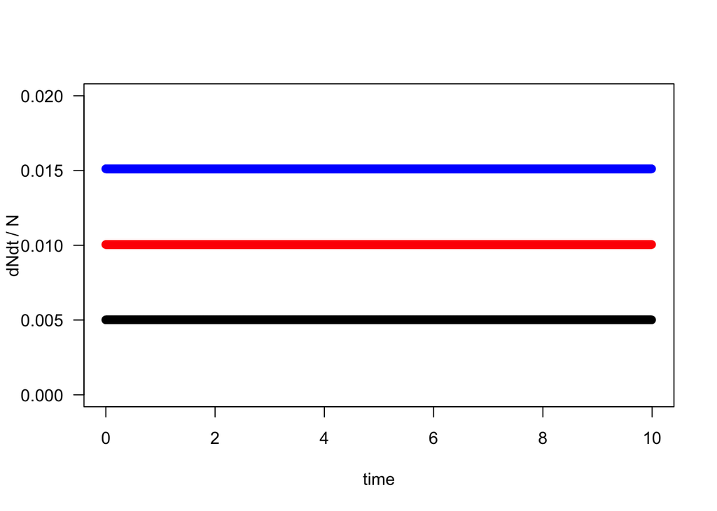

```r
der_per.ind0.5 <- diff0.5/r0.5t
der_per.ind1.0 <- diff1.0/r1.0[-len.t]
der_per.ind1.5 <- diff1.5/r1.5[-len.t]
plot(x = NA, type = "n", xlab = "time", ylab = "dNdt / N", xlim = c(0, max(times)), ylim = c(0, .02), las = 1)
  points(x = times[-len.t], y = der_per.ind0.5)
  points(x = times[-len.t], y = der_per.ind1.0, col = "red")
  points(x = times[-len.t], y = der_per.ind1.5, col = "blue")
```

Dividing the rate of change by the number of individuals gives you the per-capita (per-individual) rate of change. Looking at the per-capita rate of change over time shows that there is no change in the reproductive rate **independent** the population size (some times there was just a single individual, others there was over 3 million!) . This graphical relationship demonastrates why the section just read is called *density-independent* change.

### 1.9

For the UN data on the global human population, plot the time series. Next, plot how much the population changes (vertical axis) for a given density. Then plot the per-capita change against density. Describe, to the best of your abilities, the relationship and speculate on the type of function that would best *describe* these data.

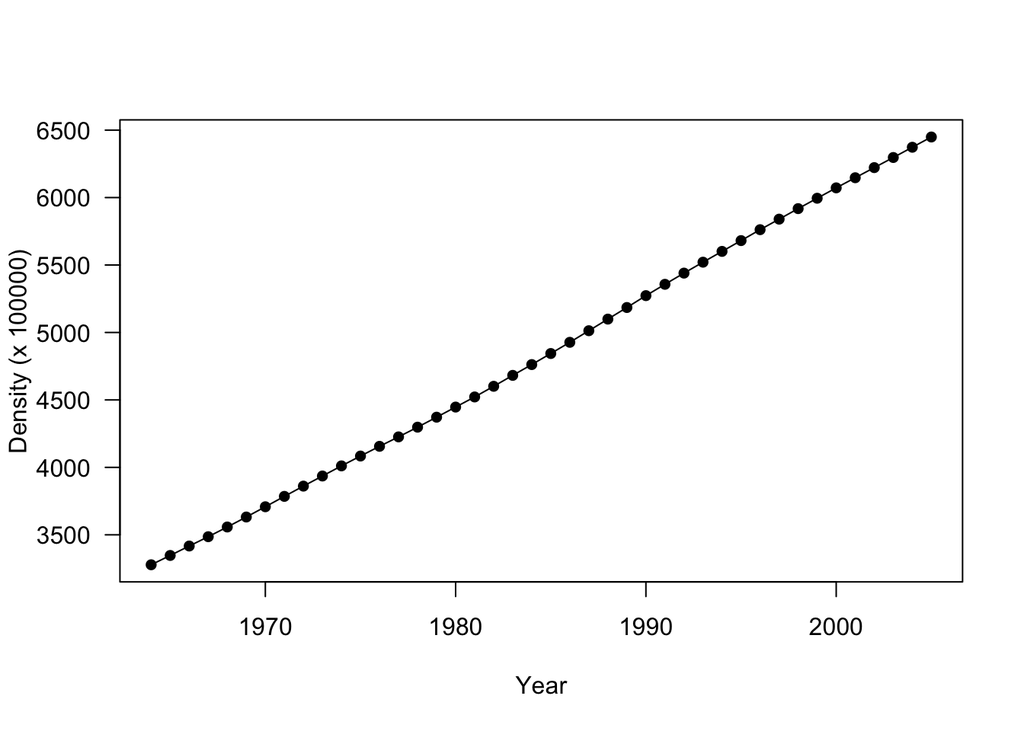

```r
pop <- c(3278, 3347, 3417, 3486, 3558, 3632, 3708, 3785, 3861, 3936, 4011, 4084, 4156, 4226, 4298, 4372, 4447, 4522, 4601, 4682, 4762, 4844, 4927, 5013, 5099, 5185, 5273, 5357, 5440, 5521, 5601, 5681, 5762, 5840, 5918, 5995, 6072, 6147, 6222, 6297, 6373, 6449)
years <- seq(from = 1964, to = 2005, by = 1)
n.years <- length(years)
popt <- pop[-n.years]
popt1 <- pop[-1]
diff.pop <- popt1 - popt
pcgr <- diff.pop/popt # pcgr = per-capita growth
plot(x = years, y = pop, xlab = "Year", ylab = "Density (x 100000)", las = 1, pch = 16)
  lines(x = years, y = pop)
```

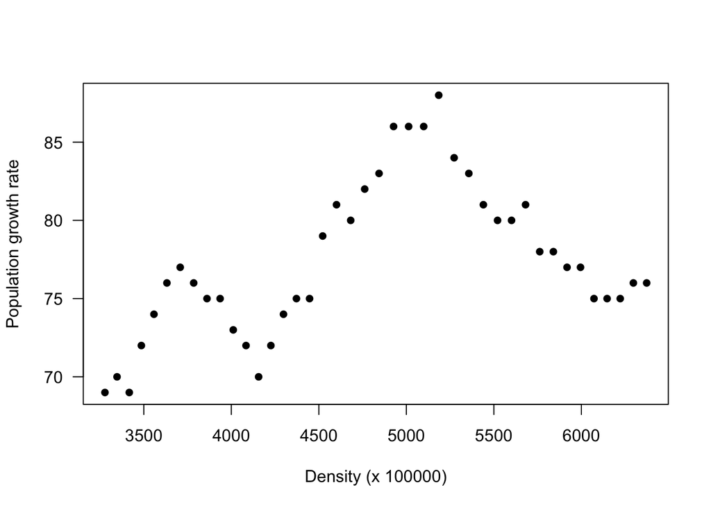

```r
plot(x = popt, y = diff.pop, xlab = "Density (x 100000)", ylab = "Population growth rate", las = 1, pch = 16)
```

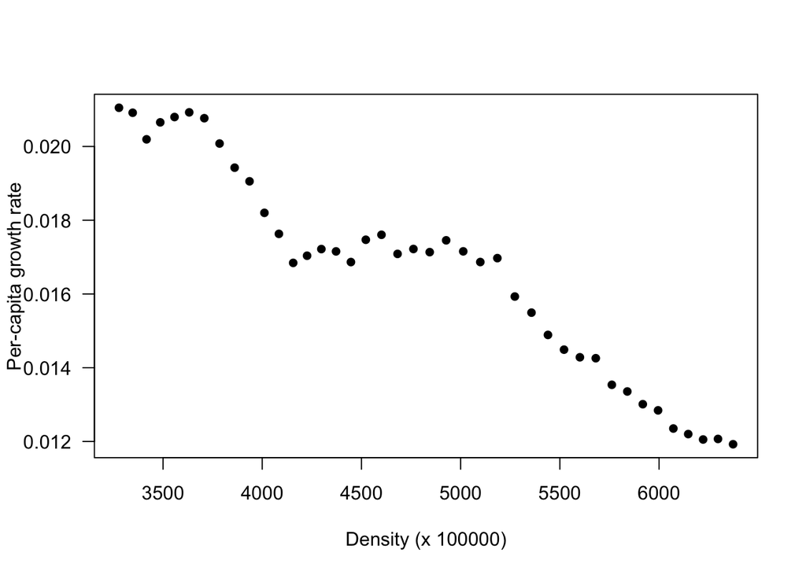

```r
plot(x = popt, y = pcgr, xlab = "Density (x 100000)", ylab = "Per-capita growth rate", las = 1, pch = 16)
```

The function is generally decreasing. If I knew nothing about population change or population size, I’d posit that it is generatlly a negatively linear relationship.

### 1.10

Graphically estimate the point at which the population population will stop growing (the number of individuals in the word at the point at which the observed trend will reach 0). How would various sections of the data, if considered alone, change your conclusions?

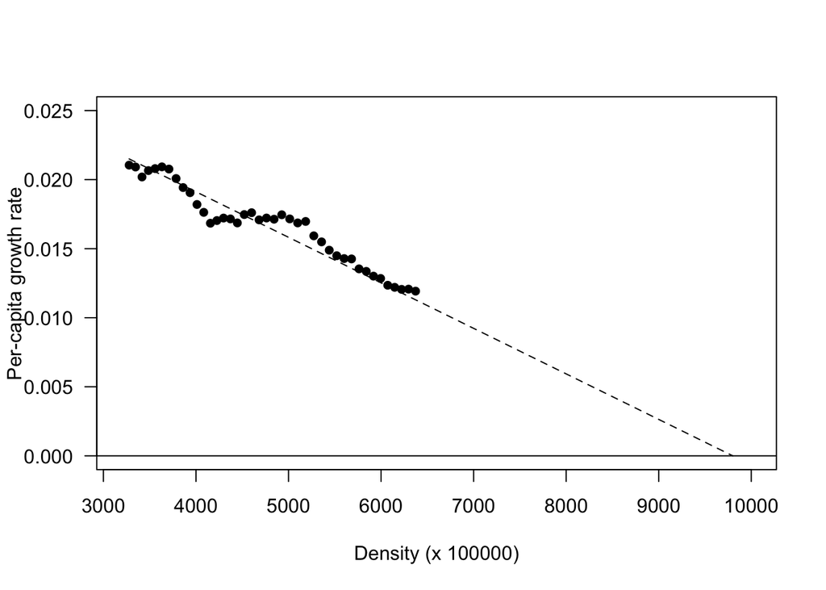

```r
plot(x = popt, y = pcgr, xlab = "Density (x 100000)", ylab = "Per-capita growth rate", las = 1, pch = 16, ylim = c(0, 0.025), xlim = c(3200, 10000))
segments(x0 = 2500, y0 = 0, x1 = 15000, y1 = 0)
segments(x0 = 3278, y0 = 0.0215, x1 = 9800, y1 = 0, lty = 2)
```

### 1.11

Using the UN data on the human population. What would be the value of the per-capita growth rate at $N = 0$? Consider and speculate on the meaning of this value.

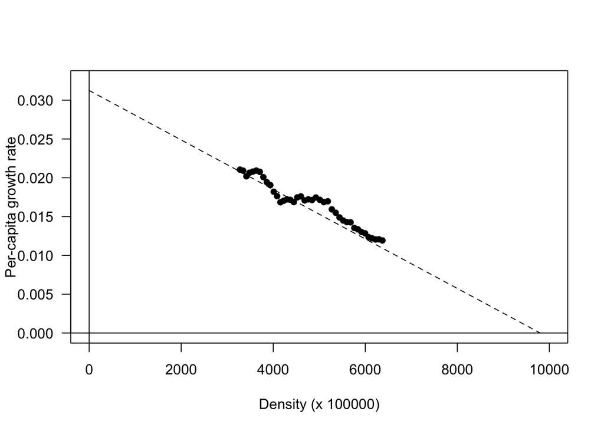

```r
plot(x = popt, y = pcgr, xlab = "Density (x 100000)", ylab = "Per-capita growth rate", las = 1, pch = 16, ylim = c(0, 0.0325), xlim = c(0, 10000))
segments(x0 = -500, y0 = 0, x1 = 15000, y1 = 0)
segments(x0 = 0, y0 = -1, x1 = 0, y1 = 1)
segments(x0 = 0, y0 = 0.03125, x1 = 9800, y1 = 0, lty = 2)
```

My visual estimate is that the per-capita growth rate when density is equal to 0 is approximately 0.03125. The estimate describes the per-capita growth rate when there is no effect of density. In other words, it is the estimate of the growth rate that is density indepdent.

### 1.12

Beginning with the exponential equation, assume that the rate of change decreases linearly with population density. Substitute $a - bN$ for $r$, and interpret $a$ and $b$ as they relate to 1.11.

The exponential eqaution is $\frac{dN}{dt} = rN$, and replacing $r$ with $a - bN$ gives us $\frac{dN}{dt} = N\left(a - bN\right)$. In this case, as the rate of change decreases linearly with population density, like 1.11, $a$ would be the per-capita growth rate when density is near 0 and $b$ would be the negative linear relationship between density and per-capita growth rate.

### 1.13

Assuming that a population grows according to the logistic equation, what is the value of the population density that will give the maximum growth rate?

The maximum population growth rate will occur when we examine the relationship between density and rate of change. We can calculte the rate of change by taking the derivative of the logistic equation with respect to $N$, and solving for $N$. Specifically:
$$\frac{\partial \frac{dN}{dt}}{\partial N} = \left(\frac{\partial \left(rN\left(\frac{K - N}{K}\right)\right)}{\partial N}\right) = r - 2r\left(\frac{N}{K}\right)$$
Setting the second derivative to 0 and solving for $N$ will give us $N^* = \frac{K}{2}$, meaning that the maximal rate of change will be at half of the carrying capacity.

### 1.14 (Skip)

### 1.15 (Skip)

### 1.16

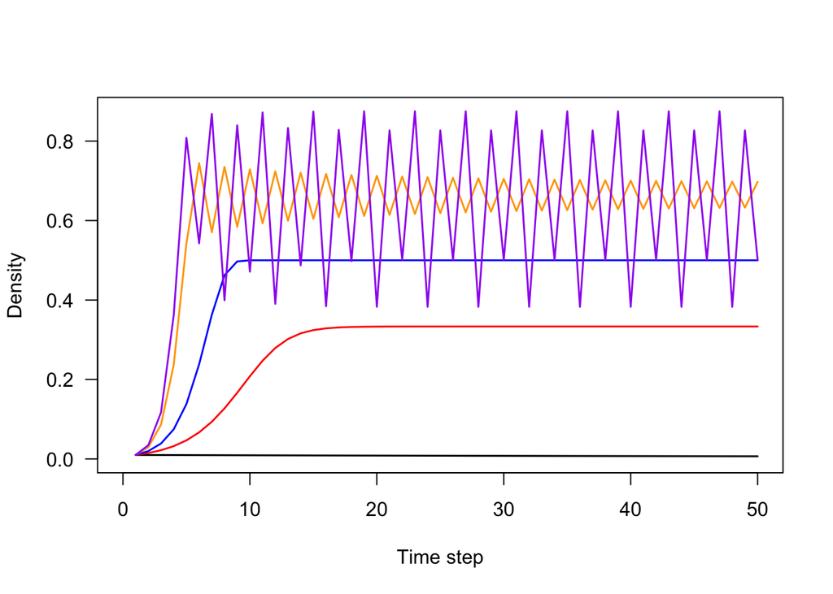

```r
N0_1.16 <- 0.01
lambda.vec <- c(1, 1.5, 2, 3, 3.5)
n.lambdas <- length(lambda.vec)
n.steps_1.16 <- 50
vec.steps_1.16 <- 1:n.steps_1.16
N.mat <- matrix(data = NA, nrow = n.lambdas, ncol = n.steps_1.16) # each row will be a
N.mat[,1] <- N0_1.16 # it fills the entire column with initial N0

for (i in 1:n.lambdas) {
  for (j in 2:n.steps_1.16) {
    N.mat[i, j] <- lambda.vec[i]*N.mat[i, j-1]*(1 - N.mat[i, j-1])
  }
}

plot(NA, type = "n", xlim = c(0, n.steps_1.16), ylim = c(0, max(N.mat)), xlab = "Time step", ylab = "Density", las = 1)
  lines(x = vec.steps_1.16, y = N.mat[1,] , lwd = 1.5) # lwd is the "line width"
  lines(x = vec.steps_1.16, y = N.mat[2,] , lwd = 1.5, col = "red")
  lines(x = vec.steps_1.16, y = N.mat[3,] , lwd = 1.5, col = "blue")
  lines(x = vec.steps_1.16, y = N.mat[4,] , lwd = 1.5, col = "orange")
  lines(x = vec.steps_1.16, y = N.mat[5,] , lwd = 1.5, col = "purple")
```

### 1.17

In exercise 1.4, successive values of population density were plotted against one another (i.e., $N_{t+1}$ was plotted against $N_t$). Repeat that exercise for $\lambda =$ 1.5, 2.0, 3.0, and 3.5, and then modify the equation to be the logistic map (eqn. 27) and make the graphs again for $\lambda =$ 1.5, 2.0, 3.0, and 3.5.

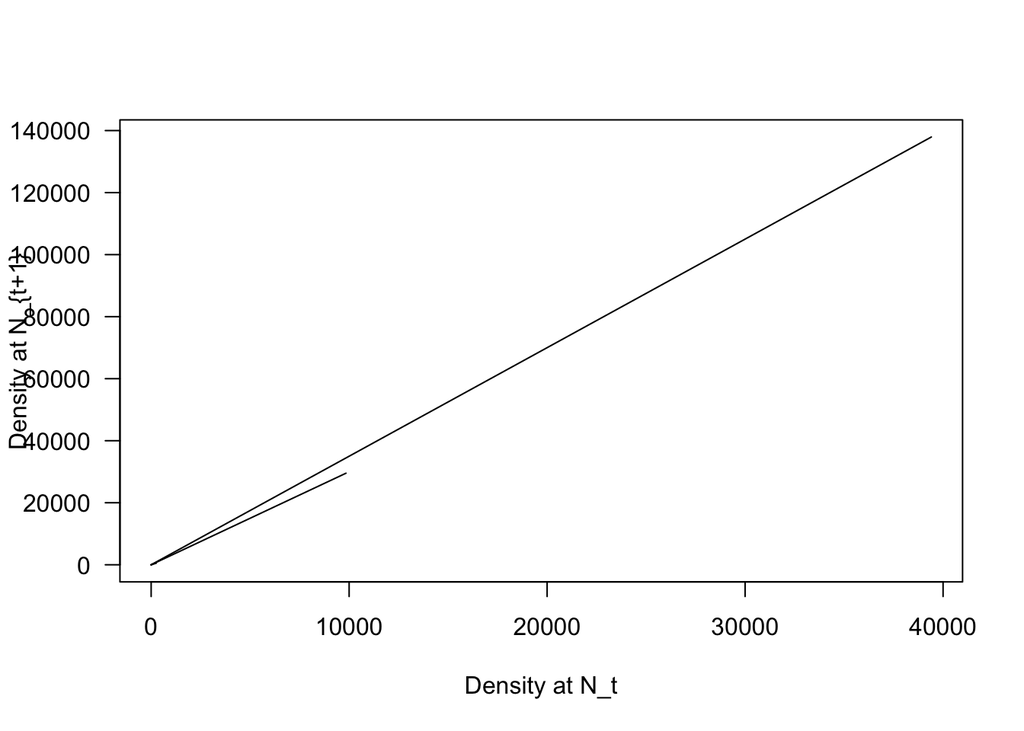

```r
N.lam_1.5 <- vector(mode = "numeric", length = 11)
N.lam_1.5[1] <- 0.5
for (i in 2:length(N.lam_1.5)) {
  N.lam_1.5[i] <- 1.5*N.lam_1.5[i-1]
}
N.lam_2.0 <- vector(mode = "numeric", length = 11)
N.lam_2.0[1] <- 0.5
for (i in 2:length(N.lam_2.0)) {
  N.lam_2.0[i] <- 2*N.lam_2.0[i-1]
}
N.lam_3.0 <- vector(mode = "numeric", length = 11)
N.lam_3.0[1] <- 0.5
for (i in 2:length(N.lam_3.0)) {
  N.lam_3.0[i] <- 3*N.lam_3.0[i-1]
}
N.lam_3.5 <- vector(mode = "numeric", length = 11)
N.lam_3.5[1] <- 0.5
for (i in 2:length(N.lam_3.5)) {
  N.lam_3.5[i] <- 3.5*N.lam_3.5[i-1]
}

plot(x = N.lam_3.5[-length(N.lam_3.5)], y = N.lam_3.5[-1], las = 1, xlab = "Density at N_t", ylab = "Density at N_{t+1}", type = "l")
lines(x = N.lam_3.0[-length(N.lam_3.0)], y = N.lam_3.0[-1])
lines(x = N.lam_2.0[-length(N.lam_2.0)], y = N.lam_2.0[-1])
lines(x = N.lam_1.5[-length(N.lam_1.5)], y = N.lam_1.5[-1])
```

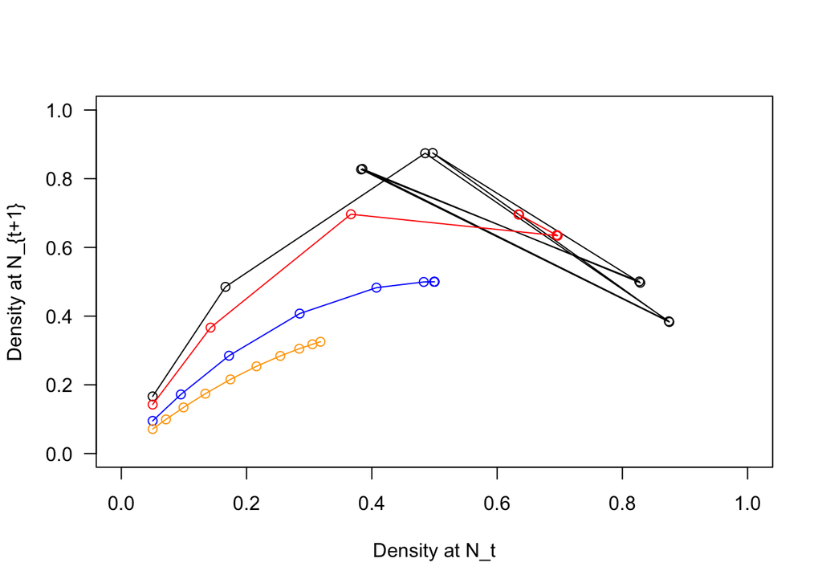

```r
N.lam_1.5_l <- vector(mode = "numeric", length = 11)
N.lam_1.5_l[1] <- 0.05
for (i in 2:length(N.lam_1.5_l)) {
  N.lam_1.5_l[i] <- 1.5*N.lam_1.5_l[i-1]*(1 - N.lam_1.5_l[i-1])
}
N.lam_2.0_l <- vector(mode = "numeric", length = 11)
N.lam_2.0_l[1] <- 0.05
for (i in 2:length(N.lam_2.0_l)) {
  N.lam_2.0_l[i] <- 2*N.lam_2.0_l[i-1]*(1 - N.lam_2.0_l[i-1])
}
N.lam_3.0_l <- vector(mode = "numeric", length = 11)
N.lam_3.0_l[1] <- 0.05
for (i in 2:length(N.lam_3.0_l)) {
  N.lam_3.0_l[i] <- 3*N.lam_3.0_l[i-1]*(1 - N.lam_3.0_l[i-1])
}
N.lam_3.5_l <- vector(mode = "numeric", length = 11)
N.lam_3.5_l[1] <- 0.05
for (i in 2:length(N.lam_3.5_l)) {
  N.lam_3.5_l[i] <- 3.5*N.lam_3.5_l[i-1]*(1 - N.lam_3.5_l[i-1])
}

plot(x = N.lam_3.5_l[-length(N.lam_3.5)], y = N.lam_3.5_l[-1], las = 1, xlab = "Density at N_t", ylab = "Density at N_{t+1}", type = "p", xlim = c(0, 1), ylim = c(0, 1))
lines(x = N.lam_3.5_l[-length(N.lam_3.5)], y = N.lam_3.5_l[-1])
points(x = N.lam_3.0_l[-length(N.lam_3.0)], y = N.lam_3.0_l[-1], col = "red")
lines(x = N.lam_3.0_l[-length(N.lam_3.0)], y = N.lam_3.0_l[-1], col = "red")
points(x = N.lam_2.0_l[-length(N.lam_2.0)], y = N.lam_2.0_l[-1], col = "blue")
lines(x = N.lam_2.0_l[-length(N.lam_2.0)], y = N.lam_2.0_l[-1], col = "blue")
points(x = N.lam_1.5_l[-length(N.lam_1.5)], y = N.lam_1.5_l[-1], col = "orange")
lines(x = N.lam_1.5_l[-length(N.lam_1.5)], y = N.lam_1.5_l[-1], col = "orange")
```

### 1.18

Plot $N_{t+1}$ against $N_t$ for the Beverton and Holt model, the Hassell model, and the Ricker model (eqns. 28–30), and compare them. Let $\lambda = 1$, $\alpha = 1$, and $b = 2$. If you wanted explore how the parameter values affect various aspects of the plot, verbally describe what you would do.

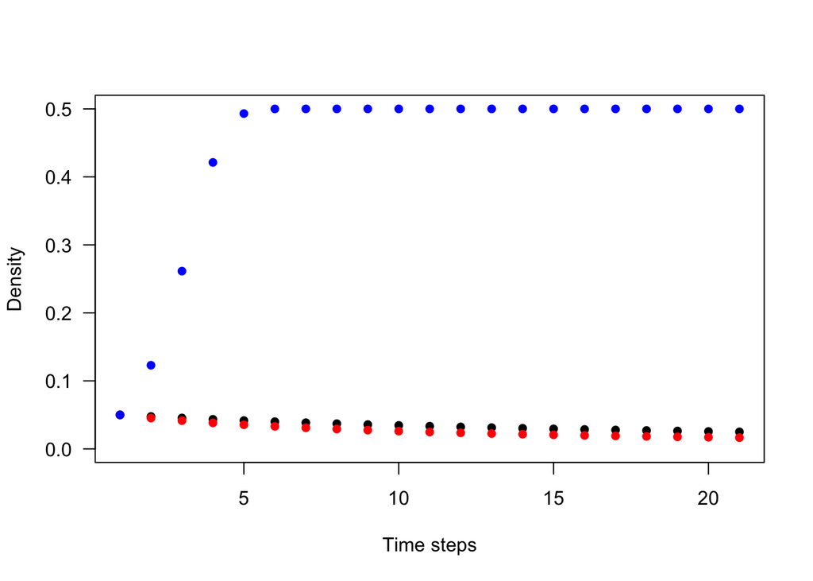

```r
steps <- 21
N_BH <- vector(length = steps, mode = "numeric")
N_H <- vector(length = steps, mode = "numeric")
N_R <- vector(length = steps, mode = "numeric")
N_BH[1] <- 0.05
N_H[1] <- 0.05
N_R[1] <- 0.05
for (i in 2:steps) {
  N_BH[i] <- (1*N_BH[i-1]) / (1 + 1*N_BH[i-1])
  N_H[i] <- (1*N_H[i-1]) / ((1 + 1*N_H[i-1])^2)
  N_R[i] <- N_R[i-1]*exp(1*(1 - 2*N_R[i-1]))
}
plot(x = 1:steps, y = N_BH, las = 1, xlab = "Time steps", ylab = "Density", ylim = c(0, 0.5), pch = 16)
points(x = 1:steps, y = N_H, col = "red", pch = 16)
points(x = 1:steps, y = N_R, col = "blue", pch = 16)
```

I would write a loop and assign a paramater a value of a sequence in the loop that I create outside of the loop.